# Carteira de Investimento de Estúdios de Cinema

Matheus Anido & Pedro Naresi

2018-12-05

## Introdução

A indústria do cinema que para nós é um meio de entretenimento, onde podemos nos divertir, nos emocionar e entrarmos em contato com a arte audiovisual que é exposta pelos produtores do filmes, pode ser ainda mais interessante para que gosta de dinheiro e de lucros. Com o crescimento de franquias de cinema, que além de consolidadas a muitos anos, são extremamente populares ao redor do mundo, os investidores estão cada vez mais interessados em comprar ações da indústria do entretenimento. O trabalho de redigido aqui, trata-se de uma análise dos grandes estúdios de cinema da atualidade, e o quão animadores são os números para que gosta de transformar dinheiro em ainda mais dinheiro. Por fim, o desenvolvimento de uma carteira de investimento com os pesos mais adequados estipulados pelos autores.

## Estruturação

### Indústria do Cinema

Em 2017 obtivemos a maior arrecadação de todos os tempos na indústria do cinema, cerca de US$ 39,92 bilhões de dólares em todo o planeta, aonde US$ 11,12 bilhões só nos EUA. Estima-se que o valor chegue aos US$ 50 bilhões até 2020. Os títulos “A bela e a fera”, “Star Wars - Os últimos Jedi” e “Velozes e furiosos 8” foram os filmes que mais arrecadaram. Os números, além de incríveis ao olhos dos leigos, é ainda mais incrível aos investidores e acionistas.

### Obtenção dos Dados

Para desenvolvimento do trabalho e obtenção dos dados foram utilizadas as seguintes bibliotecas:

```r
library(tidyverse)
library(ggthemes)
library(gplots)
library(knitr)
library(quantmod)
library(rmarkdown)
library(shiny)
library(xts)
library(ggplot2)
library(TTR)
library(tidyquant)
library(gridExtra)
```

Foram selecionadas quatro grandes empresas do setor de produção cinematográfica para o estudo durante um período de 3 anos. A partir da biblioteca *quantmod* podemos usar a função `getSymbols` e carregar as informações direto do *Yahoo Finance*.

## Análise Fundamentalista

A Análise fundamentalista é a análise da situação financeira, econômica e mercadológica de uma empresa, um setor ou dado econômico, uma commodity ou uma moeda e suas expectativas e projeções para o futuro.

### Análise dos Dados Individuais

#### The Walt Disney Company (NYSE: DIS)

The Walt Disney Company, conhecida simplesmente como Disney, é uma companhia multinacional estadunidense de mídia de massa sediada no Walt Disney Studios, em Burbank, Califórnia. Em dezembro de 2017 após a compra da 21st Century Fox, a empresa se tornou o maior conglomerado de mídia e entretenimento do planeta por receita, passando assim a Comcast.

| **Indicador** | **Valor** |
| --- | --- |
| Capitalização de Mercado | $173.594.000.000,00 |
| Lucro Líquido Méd. a Comum (ttm) | $12.600.000.000,00 |
| Patrimônio Líquido Total | $48.773.000.000,00 |
| Lucro pro Ação Diluído (ttm) | 8,36 |
| Retorno Sobre o Patrimônio Líquido (ttm) | 26,10% |
| Rendimento Anual de Dividendos Futuros | 1,50% |
| Número de Ações | 1.503.108.494,24 |

Sony Corporation é uma empresa multinacional japonesa, sendo o quinto maior conglomerado de mídia do planeta. também atua na indústria do entretenimento sendo proprietária dos estúdios de cinema Columbia Tri-Star Pictures (Sony Pictures) e posteriormente adquiriu a Metro-Goldwyn-Mayer (MGM), porém sem a franquia de Tom e Jerry, pois essa franquia não foi vendida e posteriormente foi afiliada a Warner Bros.

[output not shown]

#### Twenty-First Century Fox, Inc. (NasdaqGS: FOX)

A 21st Century Fox é uma empresa multinacional americana de meios de comunicação em massa sediada em Midtown Manhattan, Cidade de Nova Iorque. É uma das duas empresas que foram formadas a partir da separação dos negócios de editoração da News Corporation em 2013, tal como foi fundada em 1979 por Rupert Murdoch.

| **Indicador** | **Valor** |
| --- | --- |
| Capitalização de Mercado | $91.780.000.000,00 |
| Lucro Líquido Méd. a Comum (ttm) | $4.930.000.000,00 |
| Patrimônio Líquido Total | $19.564.000.000,00 |
| Lucro pro Ação Diluído (ttm) | 2,63 |
| Retorno Sobre o Patrimônio Líquido (ttm) | 25,67% |
| Rendimento Anual de Dividendos Futuros | 0,74% |
| Número de Ações | 1.871.915.153,98 |

#### Comcast Corporation (NasdaqGS: CMCSA)

A Comcast Corporation é um conglomerado de mídia e entretenimento dos Estados Unidos, fundado no ano de 1963. Em sua lista de aquisições, encontra-se a empresa NBC Universal, a produtora de animações DreamWorks e várias outras empresas.

| **Indicador** | **Valor** |
| --- | --- |
| Capitalização de Mercado | $179.340.000.000,00 |
| Lucro Líquido Méd. a Comum (ttm) | $24.200.000.000,00 |
| Patrimônio Líquido Total | $68.606.000.000,00 |
| Lucro pro Ação Diluído (ttm) | 5,18 |
| Retorno Sobre o Patrimônio Líquido (ttm) | 37,03% |
| Rendimento Anual de Dividendos Futuros | 2,03% |
| Número de Ações | 4.597.282.448,01 |

### Interpretação dos Dados

Como uma análise fundamentalista completa é composta por inúmeros indicadores e se torna muitas vezes muito complexa, foram escolhidos apenas alguns indicadores para assim realizar a comparação com as outras companhias escolhidas.

#### P/VP

O indicador a ser verificado é a divisão entre a Capitalização de Mercado e o Patrimônio Líquido Total, que informa quanto o mercado está disposto a pagar sobre o Patrimônio Líquido da empresa (quanto o valor mais próximo de 1, melhor). Podemos certificar que mesmo com a consolidação da DIS a CMCSA é mais recomendada ao investimento.

[output not shown]

#### LPA

O indicador a ser verificado agora, Lucro por Ação Diluído, é Lucro Líquido nos últimos doze meses dividido pelo número de ações disponíveis no mercado. Podemos assim, certificar o quão lucrativa uma única ação foi nos últimos doze meses. Quanto maior esse valor, mais lucrativa ela é. Ao analisar a tabela podemos ver que a DIS eé disparada a que mais lucra no segmento, se tornando a preferidada ao analisarmos o indicador de LPA.

[output not shown]

#### ROE

[output not shown]

#### Div. Yield

Outro indicador interessante a ser verificado é o Rendimento Anual de Dividendos Futuros, que é o quanto uma empresa paga em dividendos em relação ao preço de suas ações a cada ano. O que buscamos aqui são empresas que pagam um dividendo alto e tem um valor de ação não tão alto. Entretanto, DY elevados são, frequentemente, indicadores de baixas perspectivas de crescimento. Um DY muito elevado pode ser um alerta de que a empresa está enfrentando dificuldades financeiras e que o mercado espera que isso seja acompanhado por cortes nos dividendos futuros. Se atentando ao dados, verificamos que a quem mais paga dividendo é a CMCSA e com um preço de ação muito menor que a gigante DIS.

[output not shown]

## Análise Técnica

### *Bollinger Bands*

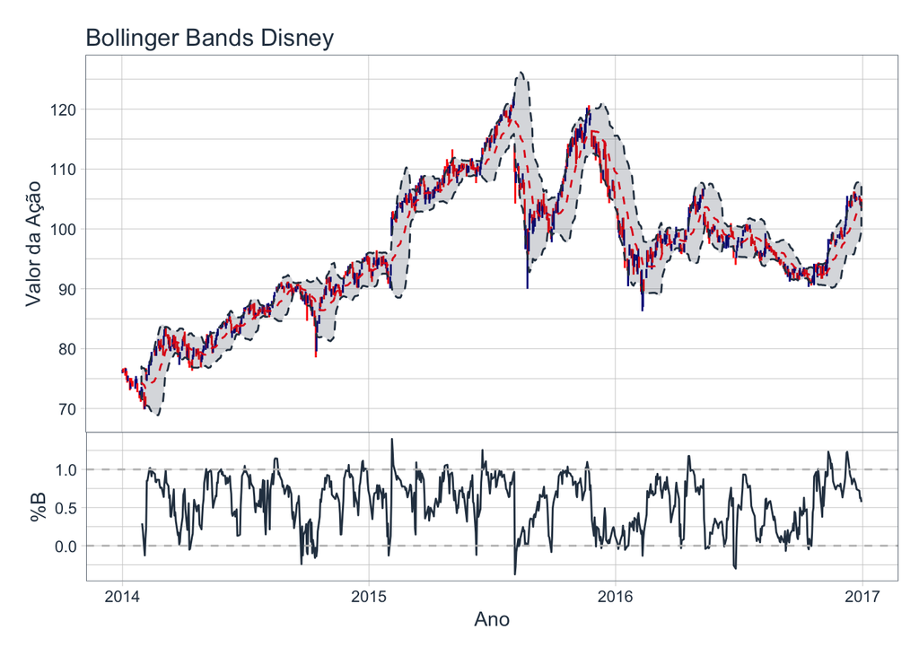

```r
plotDIS <- ggplot(data = bbands.DIS, aes(x = date, y = close, open = open, close = close, low = low, high = high)) + geom_candlestick()
plotDIS <- plotDIS + geom_bbands(ma_fun = EMA, sd = 2, n = 20, linetype = 2, size = 0.5, alpha = 0.2, fill = palette_light()[[1]], color_bands = palette_light()[[1]], color_ma = palette_light()[[2]])
plotDIS <- plotDIS + labs(title = "Bollinger Bands Disney", x = NULL, y = "Valor da Ação")
plotDIS <- plotDIS + theme_tq() + theme(axis.title.x=element_blank(), axis.text.x=element_blank(), axis.ticks.x=element_blank(),plot.margin=unit(c(0.5,0.4,0,0.5), "cm"))
plotDIS <- plotDIS + scale_y_continuous()
plotDIS2 <- ggplot(data = bbands.DIS, aes(date, pctB)) + geom_line(colour = palette_light()[[1]])
plotDIS2 <- plotDIS2 + geom_hline(yintercept = 0:1, colour = "gray", linetype = 2,size = 0.5)
plotDIS2 <- plotDIS2 + labs(x = "Ano", y = "%B")
plotDIS2 <- plotDIS2 + theme_tq()+ theme(plot.margin=unit(c(-0.1,0.4,0.5,0.6), "cm"))
grid.arrange(plotDIS,plotDIS2, nrow = 2, heights=c(2/3, 1/3))
```